# Stastics and Probebility Computer Assignment 2

## Department of Electrical and Computer Engineering

## Mohammad Taha Majlesi 810101504

[figure not shown]

Question 1:

[figure not shown]

relation between Binomial Destribution and Poisson Destribution

for Binomial Destribution we have this formula: E[Y ] = np Var(Y) = np(1-p) = npq that n is number of trials and p is probability of success and q is probability of failure part 1:

[figure not shown]

```python
import  numpy as np
def sample_binomial_distribution(m, n, p):
    samples = np.random.choice([0, 1], size=(m, n), p=[1-p, p])
    sums = np.sum(samples, axis=1)
    return sums
```

in this function we have m number of samples that has binoial destribution with n number of trials and p probability of success becuse we have n number of bernouli destribution and we want to sum them up we can use binomial destribution for this problem out put of this function is m number of samples that has binomial destribution with n number of trials and p probability of success we have n number of bernouli destribution and we want to sum them up we can use binomial destribution for this problem .

part 2:

[figure not shown]

```python
n = 500

#for that we need 100 of p values for several p values
#for generating P values
p_values = np.linspace(0,1,101)

# for generating 10000 samples of binomial destribution
m = 5000


##  this are theoretical values for binomial distribution for all of p values in numpy array that named theoretical_means and theoretical_variances
theoretical_means = n * p_values  # theoretical mean for all of p values
theoretical_variances = n * p_values * (1 - p_values)  #theoretical variance for all of p values
```

this is example of how linespace function works for example we want 100 numbers between 0 and 1 like part 2 of question 1 we put it 101 because that we want 0 and 1 too

```python
p_values = np.linspace(0,1,101)
print(p_values)
```

[output not shown]

```python
import matplotlib.pyplot as plt

sample_means = np.zeros(len(p_values))
sample_variances = np.zeros(len(p_values))

for i, p in enumerate(p_values):
    # for all of 100 p values we generate 5000 samples of binomial destribution and get that samples mean and variance and put them in sample_means and sample_variances arrays
    samples = sample_binomial_distribution(m, n, p)
    sample_means[i] = np.mean(samples)
    sample_variances[i] = np.var(samples)

# plot the results
plt.figure(figsize=(20, 20))
plt.plot(p_values, theoretical_means, label="theoretical mean")
plt.plot(p_values, sample_means, label="practical mean")
plt.plot(p_values, theoretical_variances, label="theoretical variance ")
plt.plot(p_values, sample_variances, label="practical variance ")
plt.xlabel("P values")
plt.ylabel("samples")
plt.legend()
plt.title("theoretical and practical  values for binomial distribution")
plt.grid(True)
plt.show()
```

[output not shown]

part 4:

[figure not shown]

we can see that mean of theoretical and practical are close to each other and variance of theoretical and practical are close to each other too but for p values near to .5 practical variance is not close to theoretical variance

## Question 2:

[figure not shown]

## part 1:

[figure not shown]

we need to show that for this problem that p is not around 0.5 we can not use normal destribution and we need to use poisson destribution it gives us better result by poisson destribution

```python
import numpy as np
import matplotlib.pyplot as plt

# fist we generate 10000 samples of binomial distribution with n = 250 and p = 0.08
n = 250
p = 0.008

# we can use binomial function in numpy for generating binomial distribution
binomial_samples = np.random.binomial(n, p, size=10000)

# plot the results
plt.hist(binomial_samples, bins=100, density=True, alpha=1, color='g')
plt.title('Binomial Distribution (n=250, p=0.008)')
plt.xlabel('Number of Occurrences')
plt.ylabel('Probability Density')
plt.show()
```

[output not shown]

```python
from scipy.stats import poisson


#poisson distribution with lambda = 2
poisson_lambda = 2

poisson_samples = poisson.rvs(mu=poisson_lambda, size=10000)

plt.hist(poisson_samples, bins=100, density=True, alpha=1, color='g')
plt.title('Poisson Distribution (lambda=20)')
plt.xlabel('Number of Occurrences')
plt.ylabel('Probability Density')
plt.show()
```

[output not shown]

```python
from math import sqrt
from scipy.stats import norm

normal_mean = 2
normal_std = sqrt(1.984)

x = np.linspace(normal_mean - 3*normal_std, normal_mean + 3*normal_std, 10000)
normal_samples = norm.pdf(x, normal_mean, normal_std)

plt.plot(x, normal_samples, 'b-', lw=2)
plt.title('Normal Distribution (mean=3182.59, std=6.47)')
plt.xlabel('Number of Occurrences')
plt.ylabel('Probability Density')
plt.show()
```

[output not shown]

[figure not shown]

poisson Destribution is better to use rather than normal for this problem so we can say that for this problem we can not use normal distribution and we need to use poisson distribution and poisson distribution is better for this problem

Question 3:

[figure not shown]

part 1 :

[figure not shown]

first we need to plot it

```python
mean = 80
std_dev = 12

normal_samples = np.random.normal(mean,std_dev,1000000)
plt.hist(normal_samples, bins=1000,density=True)
plt.show()
```

[output not shown]

now we need to calculate score if it be in 10 top score we can use ppf function in scipy.stats.norm for this part

```python
top_10_score = norm.ppf(0.90, loc=mean, scale=std_dev)
print(f"The top 10 score: {top_10_score:.2f}")
```

[output not shown]

Part 2:

[figure not shown]

```python
second_quartile_score = norm.ppf(0.5, loc=mean, scale=std_dev)
third_quartile_score = norm.ppf(0.75, loc=mean, scale=std_dev)
print(f"The second quartile score: {second_quartile_score:.2f}")
print(f"The third quartile score: {third_quartile_score:.2f}")
```

[output not shown]

Part 3:

[figure not shown]

we can use CDF for this part we can use cdf function in scipy.stats.norm for this part that calculate it from normal distribution function CDF

```python
prob_between_80_90 = norm.cdf(90, loc=mean, scale=std_dev) - norm.cdf(80, loc=mean, scale=std_dev)
print(f"The probability of a score between 80 and 90: {prob_between_80_90:.4f}")
```

[output not shown]

Part 4:

[figure not shown]

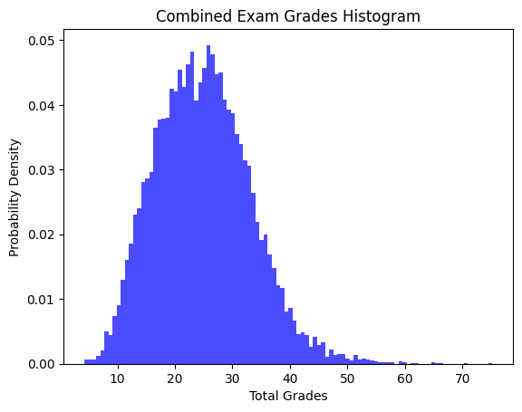

```python
import numpy as np
import matplotlib.pyplot as plt

#first we need to put random seed for generating same random numbers
np.random.seed(42)

num_samples = 10000

physics_grades_uniform = np.random.uniform(low=0, high=20, size=num_samples)
programming_grades_exponential = np.random.exponential(scale=5, size=num_samples)
math_grades_poisson = np.random.poisson(lam=10, size=num_samples)

total_grades = physics_grades_uniform + programming_grades_exponential + math_grades_poisson

plt.hist(total_grades, bins=100, density=True, alpha=0.7, color='blue')
plt.title('Combined Exam Grades Histogram')
plt.xlabel('Total Grades')
plt.ylabel('Probability Density')
plt.show()
```

for each of this physics math nad advance programming we have 10000 samples now this is description for each parts .

first Physics grades are uniformly distributed between 0 and 20

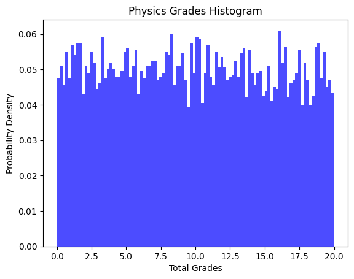

```python
physics_grades_uniform = np.random.uniform(low=0, high=20, size=num_samples)

plt.hist(physics_grades_uniform, bins=100, density=True, alpha=0.7, color='blue')
plt.title('Physics Grades Histogram')
plt.xlabel('Total Grades')
plt.ylabel('Probability Density')
plt.show()
```

Math grades are Poisson distributed with a mean of 10 as we can see it is poisson destribution with mean of 10 becuse mean of 0 - 20 is 10

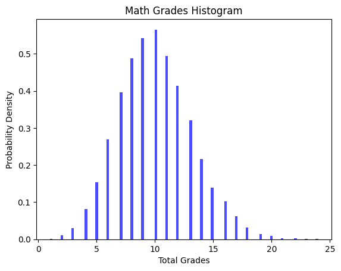

```python
math_grades_poisson = np.random.poisson(lam=10, size=num_samples)

plt.hist(math_grades_poisson, bins=100, density=True, alpha=0.7, color='blue')
plt.title('Math Grades Histogram')
plt.xlabel('Total Grades')
plt.ylabel('Probability Density')
plt.show()
```

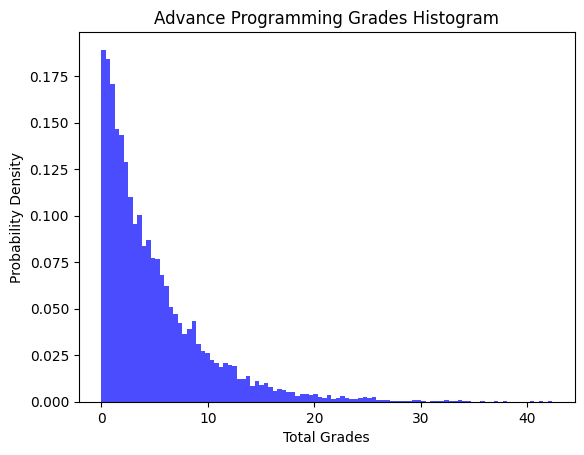

```python
programming_grades_exponential = np.random.exponential(scale=5, size=num_samples)

plt.hist(programming_grades_exponential, bins=100, density=True, alpha=0.7, color='blue')
plt.title('Advance Programming Grades Histogram')
plt.xlabel('Total Grades')
plt.ylabel('Probability Density')
plt.show()
```

Question 4:

[figure not shown]

part 1:

[figure not shown]

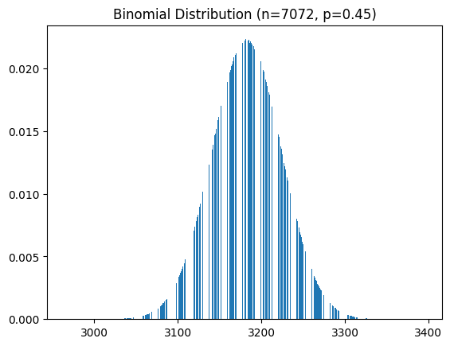

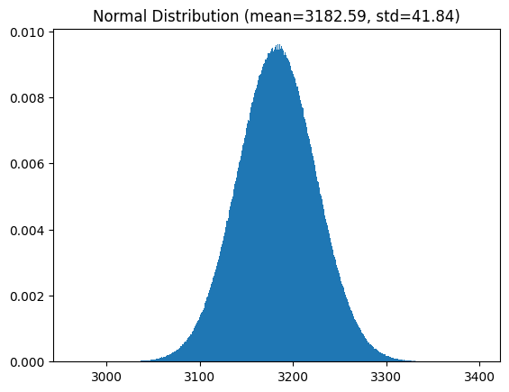

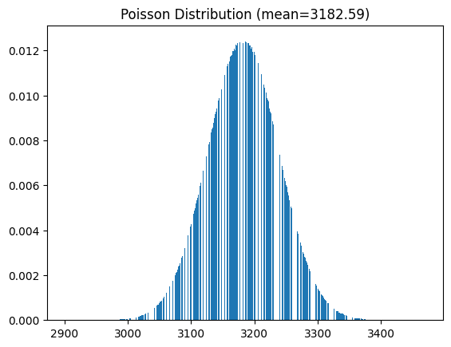

```python
main_destribution = np.random.binomial(7072,0.45,size=10000000)
plt.hist(main_destribution, bins=1000,density=True)
plt.title('Binomial Distribution (n=7072, p=0.45)')
plt.show()

normal_approximation = np.random.normal(3182.59,41.84,size=10000000)
plt.hist(normal_approximation, bins=1000,density=True)
plt.title('Normal Distribution (mean=3182.59, std=41.84)')
plt.show()

poisson_approximation = np.random.poisson(3182.59,size=10000000)
plt.hist(poisson_approximation, bins=1000,density=True)
plt.title('Poisson Distribution (mean=3182.59)')
plt.show()
```

part 2:

[figure not shown]

normal destribution has more fit to binomial destribution